# Assignment 6: Trees and Random Forest

# Question 1

```r
# [10 points] PCA (Principal Component Analysis) is an unsupervised ML method that is often used to reduce dimensionality of large data sets.
# 1. Please explain how PCA can be used to reduce the number of variables.
# 2. Please highlight limitations of PCA.
```

1.1 PCA (Principal Component Analysis) functions by transforming a large set of variables into a smaller set of components that contain the most important information of the original dataset. If the original dataset has 10 dimensions/variables, PCA might select only the first 2-3 principal components with all PCs ordered by variance of the fitted projection. By plotting high-dimensional data into low-dimensional space, PCA reduces the dimensionality of large data sets.

During this process, the PCs are found by looking for high-variance projections from multivariate x (variable) and finds the least squares fit. All the PCs are orthogonal/perpendicular to each other, with the first(second) principal component pointing to the most(second most) variance in the data.

1.2 While PCA is good at plotting, it does a poor job in interpreting the meaning of the principal components PC1, PC2, PC3, etc. The limitation of little interpretability is due to the fact that every PC is a combination of various x variables multiplied by their corresponding loadings. Hence, it is hard to interpret and get practical business insights from the results of PCA.

For example, in the protein dataset, the first PC is composed of positive coefficients for “Cereal” and “Nuts”, and negative coefficients for “Red/White Meat”, “Eggs”, “Milk” and so on. PC1 is thus high nut/grain, low meat/diary. The interpretation of PC1 would then be as complicated as “PC1 means less eggs and meat, and a little bit less fish, and more cereal and nuts…”

# Question 2

```r
# [40 points] Trees are supervised algorithms that can be used for both regression and classification tasks. For the following trees, please explain how it is grown (i.e., how to select the variables to split on at each node)
# 1. Classification Tree
# 2. Regression Tree
```

For both types of trees, the selection of decision nodes is based on the same goal to minimize deviance. However, the computation of deviance is different in the two cases.

2.1 Classification Tree

The classification deviance is calculated as adding the log values of all estimated class probabilities in the same child node and taking the negative value of the total sum. The formula is written as classification deviance = - Σ [log(pi_hat)]. The optimal split is when the variable chosen for split decision brings about the lowest deviance.

The classification tree grows by first splitting the root node of data into two child nodes, and then use each child set as the new “parent” node to further split into new “child” nodes. At each tree level, we find the optimal split for dividing the “parent” into two homogeneous subsets. Every “child” becomes the “parent” at the next level, and we look again for the optimal split on their new children (the grandchildren).

The stopping criteria for growing trees can be based on the minimum size of the leaf nodes (i.e. the child nodes at the last level), or the minimum proportion of deviance improvement for proceeding with a new split, or the maximum number of levels in the entire tree. We stop splitting and growing when the size of the leaf nodes hits the minimum threshold (e.g., no less than 10 obs per leaf), or the % of deviance improvement hits the minimum threshold, or the number of tree levels reaches the upper limit.

2.2 Regression Tree

The regression deviance is calculated as the sum of squared errors of predicted values in the two child nodes in a split. The formula is written as regression deviance = Σ (y-y_hat)^2. The optimal split is when the variable chosen for split decision brings about the lowest sum of deviance from the left and right branch of child sets.

Similar to classification tree, regression trees grow through a sequence of splits, and we implement the splits recursively and greedily. The optimal split is found with the lowest deviance at each tree level, while the trees stops splitting and growing when it meets the stopping threshold.

# Question 3

```r
# [10 points] Please explain how a tree is pruned?
```

We prune a decision tree by removing split rules from the bottom up. At each step, we remove the split that contributes least to deviance reduction, thus reversing CART tree’s growth process. Since each prune step produces a candidate tree model with selected variables of its decision nodes, we can compare the out-of-sample prediction performance of theses candidates to choose the “best” one with minimum OOS deviance.

Cross validation is often used here. For every candidate tree yielded from pruning, we divide the dataset into k folds/subsets, with (k-1) folds as the training set and the left-out one as the test set. We get the tree model from training data, and then evaluate the OOS deviance of the pruned tree using the test set. Repeat the same process k times with a different subset used as the test set. Take the average of all k values of OOS deviance to assess this candidate.

For each prune step, repeat the procedures and find the candidate that yields the lowest OOS deviance. This candidate is the best pruned tree that we decide to use.

# Question 4

```r
# [10 points] Please explain why a Random Forest usually outperforms regular regression methods (such as linear regression, logistic regression, and lasso regression).
```

Random Forest works by averaging over a bootstrapped sample of trees. RF usually outperforms regular regression methods because it avoids “optimizing to noise” and stabilizes the prediction result by considering an average of tree fits to many different subsets. In capturing the non-linearity and interaction among variables in the dataset, decision trees do a better job than regression models. Random Forest performs even better than pruned CART trees because the algorithm benefits from model averaging.

# Question 5

```r
# [30 points] Use the Trasaction.csv dataset to create payment default classifier ('payment_default ' column) and explain your output using:
# 1. Classification Tree (CART)
# 2. Random Forest
```

```r
# Load the dataset
Transaction <- read.csv("Transaction.csv")
head(Transaction)
```

```
##   ID LIMIT_BAL SEX EDUCATION MARRIAGE AGE PAY_0 PAY_2 PAY_3 PAY_4 PAY_5 PAY_6
## 1  1     20000   2         2        1  24     2     2    -1    -1    -2    -2
## 2  2    120000   2         2        2  26    -1     2     0     0     0     2
## 3  3     90000   2         2        2  34     0     0     0     0     0     0
## 4  4     50000   2         2        1  37     0     0     0     0     0     0
## 5  5     50000   1         2        1  57    -1     0    -1     0     0     0
## 6  6     50000   1         1        2  37     0     0     0     0     0     0
##   BILL_AMT1 BILL_AMT2 BILL_AMT3 BILL_AMT4 BILL_AMT5 BILL_AMT6 PAY_AMT1 PAY_AMT2
## 1      3913      3102       689         0         0         0        0      689
## 2      2682      1725      2682      3272      3455      3261        0     1000
## 3     29239     14027     13559     14331     14948     15549     1518     1500
## 4     46990     48233     49291     28314     28959     29547     2000     2019
## 5      8617      5670     35835     20940     19146     19131     2000    36681
## 6     64400     57069     57608     19394     19619     20024     2500     1815
##   PAY_AMT3 PAY_AMT4 PAY_AMT5 PAY_AMT6 payment_default
## 1        0        0        0        0               1
## 2     1000     1000        0     2000               1
## 3     1000     1000     1000     5000               0
## 4     1200     1100     1069     1000               0
## 5    10000     9000      689      679               0
## 6      657     1000     1000      800               0
```

```r
# View(Transaction)
```

```r
# Preprocess data
library(dplyr)
Transaction$payment_default <- as.factor(Transaction$payment_default)

# View dataset
head(Transaction)
```

```
##   ID LIMIT_BAL SEX EDUCATION MARRIAGE AGE PAY_0 PAY_2 PAY_3 PAY_4 PAY_5 PAY_6
## 1  1     20000   2         2        1  24     2     2    -1    -1    -2    -2
## 2  2    120000   2         2        2  26    -1     2     0     0     0     2
## 3  3     90000   2         2        2  34     0     0     0     0     0     0
## 4  4     50000   2         2        1  37     0     0     0     0     0     0
## 5  5     50000   1         2        1  57    -1     0    -1     0     0     0
## 6  6     50000   1         1        2  37     0     0     0     0     0     0
##   BILL_AMT1 BILL_AMT2 BILL_AMT3 BILL_AMT4 BILL_AMT5 BILL_AMT6 PAY_AMT1 PAY_AMT2
## 1      3913      3102       689         0         0         0        0      689
## 2      2682      1725      2682      3272      3455      3261        0     1000
## 3     29239     14027     13559     14331     14948     15549     1518     1500
## 4     46990     48233     49291     28314     28959     29547     2000     2019
## 5      8617      5670     35835     20940     19146     19131     2000    36681
## 6     64400     57069     57608     19394     19619     20024     2500     1815
##   PAY_AMT3 PAY_AMT4 PAY_AMT5 PAY_AMT6 payment_default
## 1        0        0        0        0               1
## 2     1000     1000        0     2000               1
## 3     1000     1000     1000     5000               0
## 4     1200     1100     1069     1000               0
## 5    10000     9000      689      679               0
## 6      657     1000     1000      800               0
```

# 5.1 Classification Tree

```r
set.seed(1)

# Use 80% of data as training set and the rest 20% as test set
train_m <- sample(1: nrow(Transaction), nrow(Transaction)*0.80)

# Split the data into two sets
Train_data <- Transaction[train_m,]
Test_data <- Transaction[-train_m,]

# Check their dimensions
dim(Train_data)
```

```
## [1] 24000    25
```

```r
dim(Test_data)
```

```
## [1] 6000   25
```

# Method 1: Using tree() function

```r
library(tree)

# Develop decision tree with training set
mytree <- tree(payment_default ~ . , data = Train_data, method = "class")
mytree
```

```
## node), split, n, deviance, yval, (yprob)
##       * denotes terminal node
##
## 1) root 24000 25270 0 ( 0.7803 0.2197 )
##   2) PAY_0 < 1.5 21493 19210 0 ( 0.8356 0.1644 )
##     4) PAY_2 < 1.5 19686 16060 0 ( 0.8584 0.1416 )
##       8) PAY_AMT2 < 1500.5 7235  7266 0 ( 0.7988 0.2012 ) *
##       9) PAY_AMT2 > 1500.5 12451  8470 0 ( 0.8930 0.1070 ) *
##     5) PAY_2 > 1.5 1807  2449 0 ( 0.5877 0.4123 ) *
##   3) PAY_0 > 1.5 2507  3089 1 ( 0.3063 0.6937 ) *
```

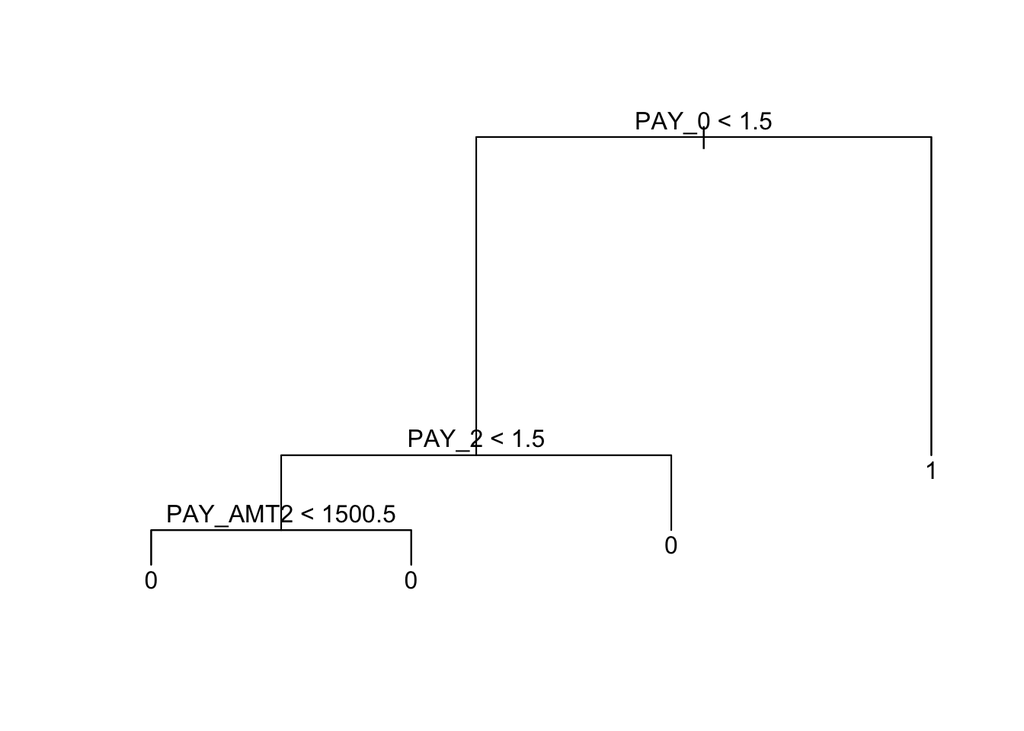

```r
# Visualize the tree structure
plot(mytree)
text(mytree)
```

```r
# Cross Validation across pruning levels
cv_tree <- cv.tree(mytree, K = 10)
cv_tree
```

```
## $size
## [1] 4 3 2 1
##
## $dev
## [1] 21321.31 21602.19 22301.00 25272.53
##
## $k
## [1]      -Inf  323.6301  699.7897 2973.2266
##
## $method
## [1] "deviance"
##
## attr(,"class")
## [1] "prune"         "tree.sequence"
```

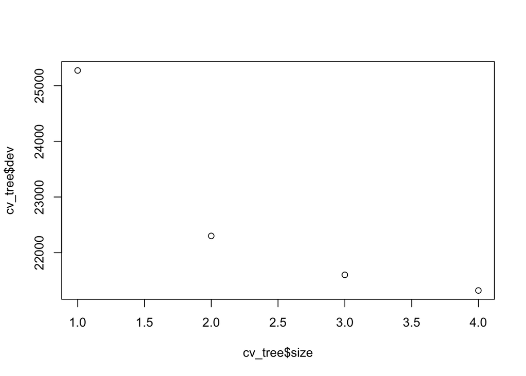

```r
# Out-0f-sample deviance is used to choose tree size:
# cv_tree$size
# cv_tree$dev
plot(cv_tree$size, cv_tree$dev)
```

```r
# Since size = 4 has the lowest CV Deviance, fit the tree with the optimal size
tree_cut <- prune.tree(mytree, k = 10, best = 4)
tree_cut
```

```
## node), split, n, deviance, yval, (yprob)
##       * denotes terminal node
##
## 1) root 24000 25270 0 ( 0.7803 0.2197 )
##   2) PAY_0 < 1.5 21493 19210 0 ( 0.8356 0.1644 )
##     4) PAY_2 < 1.5 19686 16060 0 ( 0.8584 0.1416 )
##       8) PAY_AMT2 < 1500.5 7235  7266 0 ( 0.7988 0.2012 ) *
##       9) PAY_AMT2 > 1500.5 12451  8470 0 ( 0.8930 0.1070 ) *
##     5) PAY_2 > 1.5 1807  2449 0 ( 0.5877 0.4123 ) *
##   3) PAY_0 > 1.5 2507  3089 1 ( 0.3063 0.6937 ) *
```

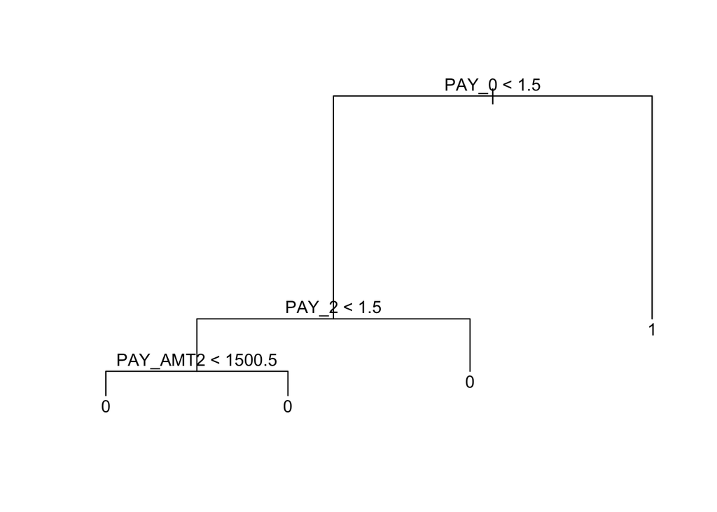

```r
plot(tree_cut)
text(tree_cut)
```

# Method 2: Using rpart() function

```r
library(rpart)
library(rpart.plot)
```

```r
# Develop a classification tree with the training set
cart_tree <- rpart(payment_default ~ ., data = Train_data, method = "class")
summary(cart_tree)
```

```
## Call:
## rpart(formula = payment_default ~ ., data = Train_data, method = "class")
##   n= 24000
##
##          CP nsplit rel error    xerror       xstd
## 1 0.1841806      0 1.0000000 1.0000000 0.01216613
## 2 0.0100000      1 0.8158194 0.8158194 0.01127005
##
## Variable importance
## PAY_0 PAY_5 PAY_4 PAY_6 PAY_3 PAY_2
##    86     4     4     3     2     2
##
## Node number 1: 24000 observations,    complexity param=0.1841806
##   predicted class=0  expected loss=0.2196667  P(node) =1
##     class counts: 18728  5272
##    probabilities: 0.780 0.220
##   left son=2 (21493 obs) right son=3 (2507 obs)
##   Primary splits:
##       PAY_0 < 1.5 to the left,  improve=1257.8790, (0 missing)
##       PAY_2 < 1.5 to the left,  improve= 946.1505, (0 missing)
##       PAY_3 < 1.5 to the left,  improve= 732.7014, (0 missing)
##       PAY_4 < 1.5 to the left,  improve= 627.6479, (0 missing)
##       PAY_5 < 1   to the left,  improve= 579.8684, (0 missing)
##   Surrogate splits:
##       PAY_5 < 2.5 to the left,  agree=0.900, adj=0.043, (0 split)
##       PAY_4 < 2.5 to the left,  agree=0.900, adj=0.041, (0 split)
##       PAY_6 < 2.5 to the left,  agree=0.899, adj=0.030, (0 split)
##       PAY_3 < 3.5 to the left,  agree=0.899, adj=0.029, (0 split)
##       PAY_2 < 2.5 to the left,  agree=0.898, adj=0.022, (0 split)
##
## Node number 2: 21493 observations
##   predicted class=0  expected loss=0.1643791  P(node) =0.8955417
##     class counts: 17960  3533
##    probabilities: 0.836 0.164
##
## Node number 3: 2507 observations
##   predicted class=1  expected loss=0.3063422  P(node) =0.1044583
##     class counts:   768  1739
##    probabilities: 0.306 0.694
```

```r
print(cart_tree)
```

```
## n= 24000
##
## node), split, n, loss, yval, (yprob)
##       * denotes terminal node
##
## 1) root 24000 5272 0 (0.7803333 0.2196667)
##   2) PAY_0< 1.5 21493 3533 0 (0.8356209 0.1643791) *
##   3) PAY_0>=1.5 2507  768 1 (0.3063422 0.6936578) *
```

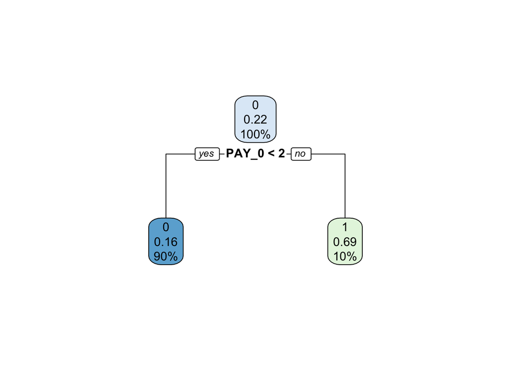

```r
# Plot the decision tree
rpart.plot(cart_tree)
```

```r
# prp(cart_tree)
```

```r
# Find the optimal cp value associated with the minimum error
# The value of cp should be least, so that the cross-validated error rate is minimum.
cart_tree$cptable[which.min(cart_tree$cptable[,"xerror"]),"CP"]
```

```
## [1] 0.01
```

```r
printcp(cart_tree) # display the results
```

```
##
## Classification tree:
## rpart(formula = payment_default ~ ., data = Train_data, method = "class")
##
## Variables actually used in tree construction:
## [1] PAY_0
##
## Root node error: 5272/24000 = 0.21967
##
## n= 24000
##
##        CP nsplit rel error  xerror     xstd
## 1 0.18418      0   1.00000 1.00000 0.012166
## 2 0.01000      1   0.81582 0.81582 0.011270
```

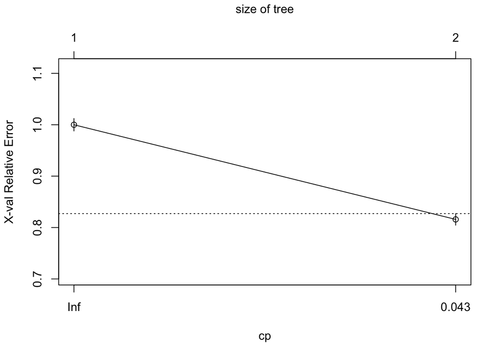

```r
plotcp(cart_tree) # visualize cross-validation results
```

```r
# Prune the tree with minimum Cp value = 0.01
pfit<- prune(cart_tree, cp=cart_tree$cptable[which.min(cart_tree$cptable[,"xerror"]),"CP"], k = 10)
pfit
```

```
## n= 24000
##
## node), split, n, loss, yval, (yprob)
##       * denotes terminal node
##
## 1) root 24000 5272 0 (0.7803333 0.2196667)
##   2) PAY_0< 1.5 21493 3533 0 (0.8356209 0.1643791) *
##   3) PAY_0>=1.5 2507  768 1 (0.3063422 0.6936578) *
```

```r
# Alternatively, post-pruning the tree with the selected CP value
# control <- rpart.control(minsplit=1000, maxdepth = 4, cp = 0.01)
cart_tree2 <- rpart(payment_default ~ ., data = Train_data, method = "class", control = rpart.control(minsplit=1000, maxdepth = 4, cp = 0.01))

# Same result
print(cart_tree2)
```

```
## n= 24000
##
## node), split, n, loss, yval, (yprob)
##       * denotes terminal node
##
## 1) root 24000 5272 0 (0.7803333 0.2196667)
##   2) PAY_0< 1.5 21493 3533 0 (0.8356209 0.1643791) *
##   3) PAY_0>=1.5 2507  768 1 (0.3063422 0.6936578) *
```

```r
# Make predictions with the pruned tree model
pred <- predict(pfit, Test_data, type = "class")
```

```r
# Construct the Confusion Matrix
table_mat <- table(Test_data$payment_default, pred)
table_mat
```

```
##    pred
##        0    1
##   0 4451  185
##   1  926  438
```

```r
# Check the accuracy of the predictions
accuracy_Test <- sum(diag(table_mat)) / sum(table_mat)
print(paste('Accuracy for test', round(accuracy_Test, digits = 5)))
```

```
## [1] "Accuracy for test 0.81483"
```

```r
# Assess the tree performance
library(caret)
confusionMatrix(pred, Test_data$payment_default)
```

```
## Confusion Matrix and Statistics
##
##           Reference
## Prediction    0    1
##          0 4451  926
##          1  185  438
##
##                Accuracy : 0.8148
##                  95% CI : (0.8048, 0.8246)
##     No Information Rate : 0.7727
##     P-Value [Acc > NIR] : 8.483e-16
##
##                   Kappa : 0.3479
##
##  Mcnemar's Test P-Value : < 2.2e-16
##
##             Sensitivity : 0.9601
##             Specificity : 0.3211
##          Pos Pred Value : 0.8278
##          Neg Pred Value : 0.7030
##              Prevalence : 0.7727
##          Detection Rate : 0.7418
##    Detection Prevalence : 0.8962
##       Balanced Accuracy : 0.6406
##
##        'Positive' Class : 0
##
```

# 5.2 Random Forest

```r
# Import library of Random Forest algorithm
library(randomForest)
# Setting seed for replicating result
set.seed(1)

# Fitting Random Forest to the training set
classifier_RF = randomForest(x = Train_data[-25],
                             y = Train_data$payment_default,
                             ntree = 500,
                             importance = TRUE) ## store necessary information for variable importance

# View classification results
classifier_RF
```

```
##
## Call:
##  randomForest(x = Train_data[-25], y = Train_data$payment_default,      ntree = 500, importance = TRUE)
##                Type of random forest: classification
##                      Number of trees: 500
## No. of variables tried at each split: 4
##
##         OOB estimate of  error rate: 17.97%
## Confusion matrix:
##       0    1 class.error
## 0 17728 1000  0.05339598
## 1  3312 1960  0.62822458
```

```r
# Alternatively...
# RF_model <- randomForest(payment_default ~ ., data = Train_data, ntree = 500, mtry = 5)
# RF_model
```

```r
# Predicting the Test set results
y_pred = predict(classifier_RF, newdata = Test_data[-25])

# Confusion Matrix, comparing predicted & actual outcomes
confusion_mtx = table(Test_data[, 25], y_pred)
confusion_mtx
```

```
##    y_pred
##        0    1
##   0 4400  236
##   1  861  503
```

```r
# Find true positive, false positive, true negative and false negative in the matrix
TN <- confusion_mtx[1,1]
FP <- confusion_mtx[1,2]
FN <- confusion_mtx[2,1]
TP <- confusion_mtx[2,2]

# Calculate the precision and recall scores of the tree model
Accuracy <- (TP + TN) /(TP + FP + TN + FN)
Precision <- TP/(TP + FP)
Recall <- TP /(TP + FN)

# Print out evaluation results
sprintf("The accuracy of the model is: %.2f%%", (Accuracy*100))
```

```
## [1] "The accuracy of the model is: 81.72%"
```

```r
sprintf("The precision score for this model is: %.2f%%", (Precision*100))
```

```
## [1] "The precision score for this model is: 68.06%"
```

```r
sprintf("The recall score for this model is: %.2f%%", (Recall*100))
```

```
## [1] "The recall score for this model is: 36.88%"
```

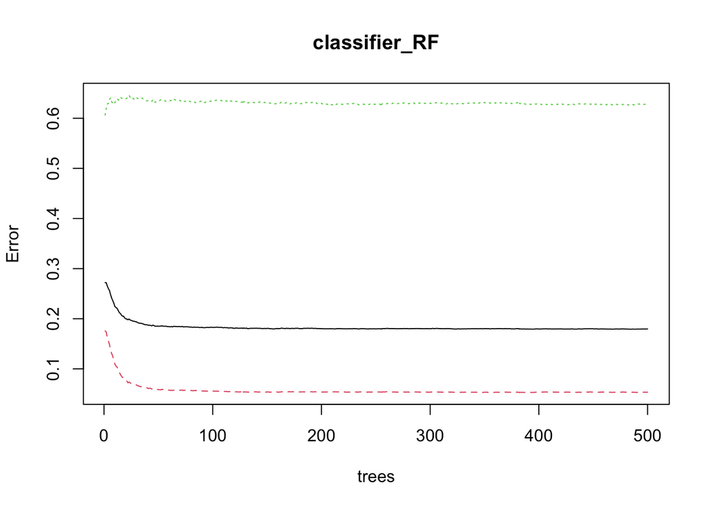

```r
# Plotting the performance of trees (x-axis represents the total number of trees in random forest; y-axis represents the error rate of classifier)
plot(classifier_RF)
```

```r
# Rank the importance of all variables (ID should be ignored as it is not a prediction factor)
importance(classifier_RF)
```

```
##                    0          1 MeanDecreaseAccuracy MeanDecreaseGini
## ID          4.899330  7.3370586             8.095697        543.59571
## LIMIT_BAL  21.088200 23.5486905            30.377157        395.17936
## SEX         3.518242  1.7030173             3.948714         81.70789
## EDUCATION   4.318694  0.1932867             4.144350        139.07947
## MARRIAGE   10.827893 -3.2815721             8.094829         95.40508
## AGE        18.884402  4.6328302            19.159339        428.54206
## PAY_0     100.848814 79.1327084           135.893275        798.78679
## PAY_2      35.059379 13.3274267            45.178465        366.24113
## PAY_3      32.485857 11.8389654            39.846160        220.27426
## PAY_4      32.001519  3.8777345            35.224457        170.27623
## PAY_5      28.669436  6.9025874            33.454290        177.83135
## PAY_6      31.085438 10.4858042            38.080002        144.39766
## BILL_AMT1  20.224359 19.8943943            31.122240        449.77704
## BILL_AMT2  36.547606 -3.8722790            43.405159        408.19538
## BILL_AMT3  40.762418 -6.4104051            46.744350        389.41079
## BILL_AMT4  42.556383 -6.7097373            50.094480        380.11726
## BILL_AMT5  33.855616  0.1687434            40.144303        374.46870
## BILL_AMT6  34.674993  2.2460699            41.703983        381.35367
## PAY_AMT1   32.532271 -1.4689461            35.892741        391.68686
## PAY_AMT2   29.788559  6.6475334            35.551818        363.50162
## PAY_AMT3   33.749771  4.4740041            40.707827        350.82655
## PAY_AMT4   26.283455  8.5587153            34.061804        331.00497
## PAY_AMT5   35.653723 -0.3364466            38.759754        327.75159
## PAY_AMT6   34.227564  7.3091019            39.145624        345.94983
```

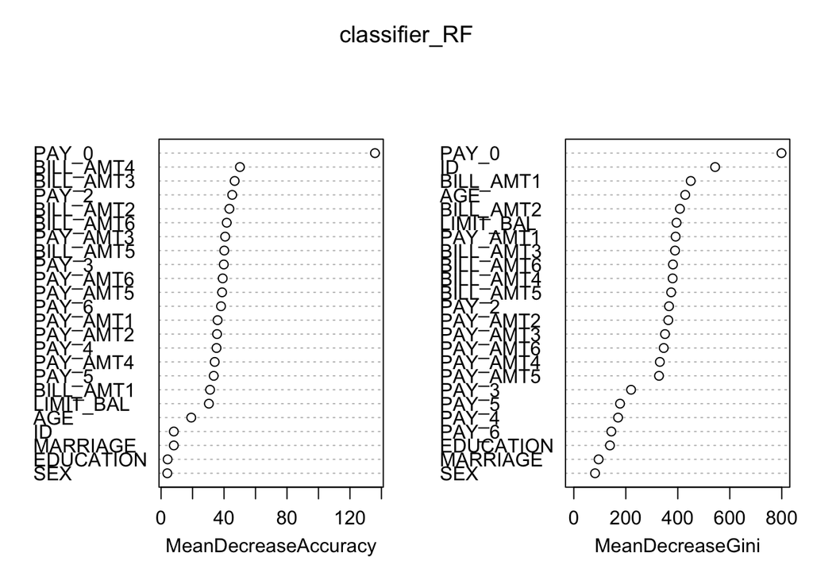

```r
# Variable importance plot (PAY_0 is the most important variable in deciding payment default classification)
varImpPlot(classifier_RF)
```

In this part, we use Random Forest to predict whether payment default will occur or not. We first built a tree model with 500 single trees from resampling, and each of them is different from others in terms of tree levels and decision nodes. We then assessed the performance of the classifier on the test dataset, resulting in an accuracy of 81.72%. By averaging prediction results from all 500 individual trees, we reduced the chance of overfitting and obtained a stable y outcome of “payment_default” (0 or 1). Unlike pruning CART (Classification) trees in the previous question, cross validation is NOT needed here.